# Ancestry assignment from allele frequencies — ieu-a / bbj (chr1)

Reported population vs AF-recovered ancestry · the τ/δ admission gate · development data

Published

July 11, 2026

## What this is

The ancestry-assignment pipeline recovers each GWAS’s ancestry from its **summary-statistic allele frequencies** (GWAS-VCF `FORMAT/AF`), because the source-declared *Reported Population* is coarse — often literally `"Mixed"` — and sometimes wrong. Each study’s frequencies are lifted GRCh37→GRCh38, fit as a non-negative sum-to-one **NNLS mixture** of the Privé (2022) UK-Biobank 21-group reference, aggregated to super-populations, and admitted to an **Assigned Ancestry** only if the dominant super-population clears a multi-gate rule: proportion **τ ≥ 0.90**, runner-up margin **δ ≥ 0.20**, overlap **≥ 20,000** reference sites, and a residual gate. Otherwise it is left **Unassigned**.

**NoteDevelopment data — chromosome 1 only**

This runs on **chr1** of a handful of real `ieu-a` / `bbj` studies, so the whole sweep takes seconds while still overlapping ~10⁵ reference sites per study. It is a development fixture for the pipeline, not a production catalogue: a genome-wide run would raise every study’s overlap (see the overlap gate below). Reported Population comes from each study’s OpenGWAS metadata and **never routes** — it only labels the points here.

## Studies

| Study | Trait | Reported | Assigned | τ (dom.) | δ (margin) | Overlap | Residual | Gate |
| --- | --- | --- | --- | --- | --- | --- | --- | --- |
| `ieu-a-2` | Body mass index | Mixed | **EUR** | 0.999 | 0.997 | 131,046 | 0.041 | ok |
| `ieu-a-7` | Coronary heart disease | Mixed | **Unassigned** | 0.762 | 0.640 | 361,446 | 0.022 | proportion |
| `ieu-a-300` | LDL cholesterol | Mixed | **EUR** | 0.977 | 0.954 | 133,229 | 0.015 | ok |
| `ieu-a-1015` | C-reactive protein | Japanese | **EAS** | 1.000 | 1.000 | 133,286 | 0.021 | ok |
| `ieu-a-11` | Crohn’s disease | East Asian | **Unassigned** | 1.000 | 1.000 | 8,286 | 0.015 | overlap |
| `ieu-a-1099` | Serum creatinine (eGFRcrea) | African American | **AFR** | 1.000 | 1.000 | 122,815 | 0.038 | ok |
| `ieu-a-1020` | Percent emphysema | Hispanic | **Unassigned** | 0.605 | 0.360 | 130,372 | 0.020 | proportion |
| `bbj-a-2` | Body mass index | East Asian | **EAS** | 0.995 | 0.991 | 330,088 | 0.018 | ok |

## The τ / δ admission gate

Each study is a point at its **dominant-super-population proportion (τ)** and **runner-up margin (δ)**, coloured by its *labelled* (Reported) population. The shaded corner is the admission region (τ ≥ 0.90 **and** δ ≥ 0.20); filled points were **assigned**, hollow points were left **Unassigned**. A study can sit inside the τ/δ corner yet still be Unassigned if it fails the orthogonal *overlap* gate (next section) — those are ringed in red.

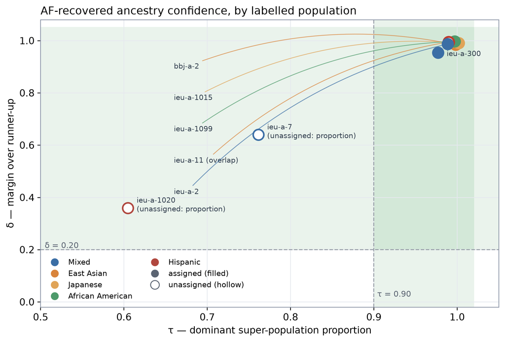

Dominant-ancestry proportion (τ) vs runner-up margin (δ), by labelled population. Shaded = admission region.

Reading it: the clean single-ancestry studies (European BMI/LDL, Japanese/East-Asian, African-American) pile in the admission corner and are assigned; the genuinely **admixed or trans-ethnic** studies fall to the left of τ and are correctly left Unassigned rather than force-labelled.

## The overlap gate (orthogonal)

Overlap is a separate gate: a study can be confidently single-ancestry (τ = δ = 1) yet still be Unassigned if too few of its variants intersect the reference on this chromosome. On chr1 alone that catches the smaller studies — a genome-wide run would clear most of them.

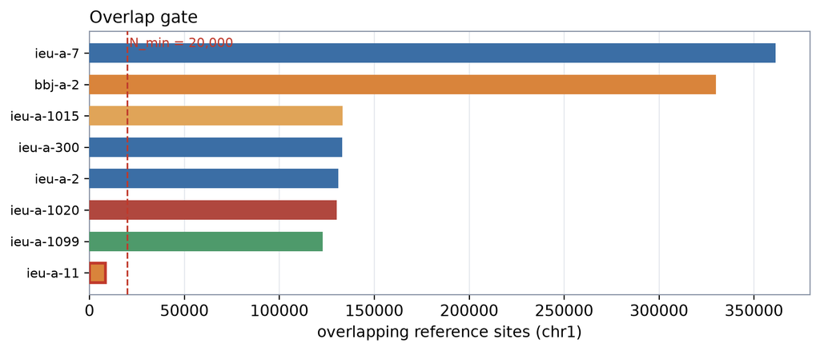

Reference-site overlap per study (chr1). Studies below the N_min line are Unassigned by the overlap gate.

## Ancestry composition

The full NNLS mixture behind each label — the super-population proportions each study’s allele frequencies decompose into.

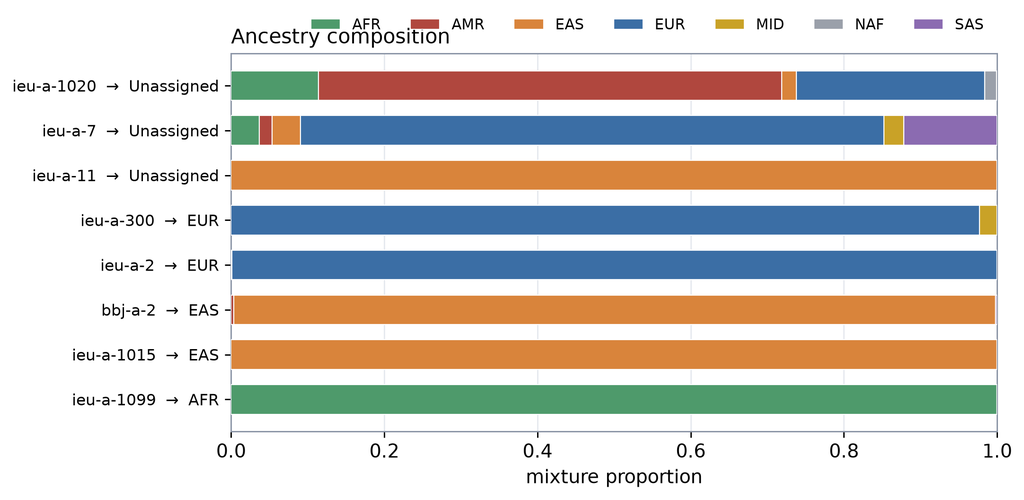

Super-population composition per study (NNLS mixture, aggregated from 21 fine groups).

## Reported vs Assigned — the audit

| Study | Reported | Assigned | Note |
| --- | --- | --- | --- |
| `ieu-a-2` | Mixed | **EUR** | declared Mixed → EUR |
| `ieu-a-7` | Mixed | **Unassigned** | declared Mixed → Unassigned |
| `ieu-a-300` | Mixed | **EUR** | declared Mixed → EUR |
| `ieu-a-1015` | Japanese | **EAS** | recovered from AF |
| `ieu-a-11` | East Asian | **Unassigned** | Unassigned (overlap) |
| `ieu-a-1099` | African American | **AFR** | recovered from AF |
| `ieu-a-1020` | Hispanic | **Unassigned** | Unassigned (proportion) |
| `bbj-a-2` | East Asian | **EAS** | recovered from AF |